# Homework 4: Functions and Tidy Data

Mickayla Johnston

10/7/2020

##### Libraries

```r
library(dplyr)
library(purrr)
library(tidyr)
library(stringr)
library(ggplot2)
```

#### 1. Write a function that takes a vector and returns one bootstrapped sample from said vector. Demonstrate that it works.

###### Write the function:

```r
boot_samp <- function(vec){

  one_boot <- sample(vec,
                     size = length(vec),
                     replace = TRUE)

  return(one_boot)

}
```

###### Show that it works:

```r
  # set seed
set.seed(123)
  # Create a test vector
vec <-rnorm(32, mean = 10, sd = 2)

  # Run the function
boot_samp(vec)
```

```
##  [1] 10.801543  6.066766  8.879049  8.749921 11.675574  8.749921 13.430130
##  [8]  7.864353  8.888318  8.626294  8.888318  6.626613 10.306746 10.852928
## [15] 13.573826  9.054417 12.507630 13.430130 12.448164  7.469878  9.564050
## [22]  9.564050 10.921832 10.852928 13.573826 10.995701  9.564050  6.066766
## [29] 10.995701  9.539645 10.141017 10.801543
```

#### 2. Write a function that, given a vector of values, a request for some number of bootstraps (let’s call the parameter R), and a sample statistic function (e.g., mean, IQR, etc.)…

##### returns R number of values of that statistic. Have it default to R = 1000 and the function is mean. Show this works for 10 bootstrapped replicate draws of a mean from some vector. Do the values look reasonable? Compare to the actual mean of the vector. Make sure you are using the function(s) you wrote in #1

```r
# Write a function that, given a vector, some # of bootstraps (r = 1000), and a sample statistic function (mean)
boot_means_fun <- function(vec, r = 1000, fun = mean){

boot_means <- replicate(r,
                        boot_samp(vec) %>%
                        mean())
# returns r # of means
return(boot_means)

}
```

###### Test it

```r
# (using same vec from previously)
boot_means_fun(vec = vec, r = 10)
```

```
##  [1] 10.037324  9.857000 10.109714 10.082691  9.099995  9.232721  9.285235
##  [8]  9.586779  9.647074 10.616070
```

###### Compare these values to the actual mean of the vector:

```r
mean(vec)
```

```
## [1] 9.919893
```

Yes, these values are relatively close to the vector mean, which is 9.919893

#### 3. Write a function that, given a vector of values, a request for some number of bootstraps, and a sample statistic function…

##### returns the original value of the statistic as applied to the vector, the mean of the statistic generated by the bootstrapped reps, the upper and lower 95% CI of the bootstrapped statistic (e.g., the 0.025 and 0.975 quantile), and the bias (i.e., the original value of the statistic - the mean of the bootstrapped statistic). Make sure you are using the function(s) you wrote in #1 and/or #2

###### Write a function that, given a vector of values, a request for some number of bootstraps, and a sample statistic function,

```r
new_fun <- function(vec, r = 1000, fun = mean){

  # returns the original value of the statistic as applied to the vector,
  true_mean <- mean(vec)

  # the mean of the statistic generated by the bootstrapped reps,
  boot_samps <- replicate(r,
                          boot_samp(vec) %>%
                            mean())

  boot_mean <- mean(boot_samps)

  # the upper and lower 95% CI of the bootstrapped statistic (e.g., the 0.025 and 0.975 quantile)

  upper_quant <- quantile(boot_mean, probs = 0.975)
  lower_quant <- quantile(boot_mean, probs = 0.025)

  # and the bias (i.e., the original value of the statistic - the mean of the bootstrapped statistic).

  bias <- (true_mean - boot_mean)

  # Return everything in a df
  out <- data.frame(true_mean = true_mean,
                    boot_mean = boot_mean,
                    lower_quant = lower_quant,
                    upper_quant = upper_quant,
                    bias = bias)

  return(out)
}
```

###### Show it works:

```r
new_fun(vec, r= 10, fun = mean)
```

```
##      true_mean boot_mean lower_quant upper_quant        bias
## 2.5%  9.919893  10.00919    10.00919    10.00919 -0.08929537
```

#### 4. FiveThirtyEight keeps a great archive of poll data at https://projects.fivethirtyeight.com/polls/. The presidential general election polling data is freely available at https://projects.fivethirtyeight.com/polls-page/president_polls.csv with question, poll id, and cycle defining a unique poll.

##### 4a. Download and look at the data. Is it long or wide?

###### Load data

```r
getwd()
```

```
## [1] "/Users/mickaylajohnston/Documents/Graduate_School/GradRStats/bio607/FA2020/homework/markdown"
```

```r
pres <- read.csv("../data/week_4/president_polls.csv")
```

###### Look at data

```r
head(pres)
```

```
##   question_id poll_id cycle          state pollster_id              pollster
## 1      131666   70576  2020 North Carolina         383 Public Policy Polling
## 2      131666   70576  2020 North Carolina         383 Public Policy Polling
## 3      131649   70573  2020                       1189       Morning Consult
## 4      131649   70573  2020                       1189       Morning Consult
## 5      131811   70578  2020           Utah        1243          Y2 Analytics
## 6      131811   70578  2020           Utah        1243          Y2 Analytics
##   sponsor_ids sponsors          display_name pollster_rating_id
## 1                      Public Policy Polling                263
## 2                      Public Policy Polling                263
## 3                            Morning Consult                218
## 4                            Morning Consult                218
## 5                               Y2 Analytics                389
## 6                               Y2 Analytics                389
##    pollster_rating_name fte_grade sample_size population population_full
```

[output cut: 41 more lines]

This is long data

##### 4b. Get just the polling data for this last week (from 9/29 to today).

###### Filter on start_date. Also filter down to just Biden and Trump (see candidate_name or answer).

###### Extra credit for using {lubridate} for this, but you can just do a messy %in% string match.

```r
library(lubridate)
```

###### Change from factor to character

```r
pres$start_date <- as.character(pres$start_date)
```

###### Change from character to date

```r
pres$start_date <- as.Date(pres$start_date, format = "%m/%d/%y")
```

###### Filter to 9/29-10/05

```r
pres_new <- pres[pres$start_date >= "2020-09-29" & pres$start_date <= "2020-10-05",]
```

###### Check pres_new to make sure we have only 9/29-10/5

```r
unique(pres_new$start_date)
```

```
## [1] "2020-10-04" "2020-10-02" "2020-10-01" "2020-09-30" "2020-09-29"
```

###### Filter to just Biden and Trump

```r
pres_new <- pres_new %>%
 filter(candidate_name == 'Joseph R. Biden Jr.' |
          candidate_name =='Donald Trump')
```

###### Check pres_new to see that we have just Biden and Trump

```r
unique(pres_new$candidate_name)
```

```
## [1] Joseph R. Biden Jr. Donald Trump
## 51 Levels: Alexandria Ocasio-Cortez Alyson Kennedy ... Wayne Messam
```

##### 4c. OK, this is your sample. What’s the bootstrapped average percentage for each candidate for nationwide polls (state == "")?

```r
# set seed
set.seed(123)

boot_cands <- pres_new %>%

  # group_by the candidate name
group_by(candidate_name) %>%

  # filter by state = "" ??
  filter(state == "") %>%

  # summarize
  summarize(boot_pcts = replicate(100,
                                # bootstrap draws
                                sample(pres_new$pct,
                             size = length(pres_new),
                             replace = TRUE)) %>%
            mean())


# view it
boot_cands
```

```
## # A tibble: 2 x 2
##   candidate_name      boot_pcts
##   <fct>                   <dbl>
## 1 Donald Trump             45.8
## 2 Joseph R. Biden Jr.      45.9
```

Average percentage for Trump is 45.81684%  
Average percentage for Biden is 45.93184%

##### 4d. What is the average difference between the two candidates by state and national polls? Note, you’ll need to make this a wide data frame to answer! And, well, try the pivot without this advice first, but then…

###### Try to pivot…

```r
pres_wide <- pres_new %>%
  pivot_wider(names_from = candidate_name,
              values_from = pct)

pres_wide
```

```
## # A tibble: 68 x 38
##    question_id poll_id cycle state pollster_id pollster sponsor_ids sponsors
##          <int>   <int> <int> <fct>       <int> <fct>    <fct>       <fct>
##  1      131666   70576  2020 "Nor…         383 Public … ""          ""
##  2      131666   70576  2020 "Nor…         383 Public … ""          ""
##  3      131649   70573  2020 ""           1189 Morning… ""          ""
##  4      131649   70573  2020 ""           1189 Morning… ""          ""
##  5      131592   70546  2020 ""            744 Ipsos    ""          ""
##  6      131592   70546  2020 ""            744 Ipsos    ""          ""
##  7      131599   70546  2020 ""            744 Ipsos    ""          ""
##  8      131599   70546  2020 ""            744 Ipsos    ""          ""
##  9      131600   70546  2020 ""            744 Ipsos    ""          ""
## 10      131600   70546  2020 ""            744 Ipsos    ""          ""
## # … with 58 more rows, and 30 more variables: display_name <fct>,
## #   pollster_rating_id <int>, pollster_rating_name <fct>, fte_grade <fct>,
## #   sample_size <int>, population <fct>, population_full <fct>,
## #   methodology <fct>, office_type <fct>, seat_number <int>, seat_name <lgl>,
## #   start_date <date>, end_date <fct>, election_date <fct>,
## #   sponsor_candidate <fct>, internal <lgl>, partisan <fct>, tracking <lgl>,
## #   nationwide_batch <lgl>, ranked_choice_reallocated <lgl>, created_at <fct>,
## #   notes <fct>, url <fct>, stage <fct>, race_id <int>, answer <fct>,
## #   candidate_id <int>, candidate_party <fct>, `Joseph R. Biden Jr.` <dbl>,
## #   `Donald Trump` <dbl>
```

###### Create unique ID, starting over again with pres_new

```r
pres_test <- pres_new %>%
  dplyr::mutate(unique_id = paste(question_id, poll_id, state, sep = "_"))
```

###### Then select the ID, state, answer, and pct. Also filter out NA diffs

```r
# now using pres_test
pres_test <- pres_test %>%
  select(unique_id, state, answer, pct)
```

###### Try pivoting:

```r
pres_test_wide2 <- pres_test %>%
  pivot_wider(names_from = answer,
              values_from = pct)
```

###### Get average by statewide polls & by nationwide polls

```r
pres_test_wide2<- pres_test_wide2 %>%
  group_by(unique_id) %>%
  mutate(diff = abs(Biden - Trump)) %>%
  filter(!is.na(diff))
# This gives us the difference between each candidate by unique id
```

###### Average diff for each state

```r
pres_test_wide3 <- pres_test_wide2 %>%
  # group by state polls
  group_by(state) %>%
  # get average difference of state polls
  mutate(avg_diff = mean(diff))
```

###### Show this average difference:

```r
final_answer <- pres_test_wide3 %>%
  select(state, avg_diff)

unique(final_answer)
```

```
## # A tibble: 10 x 2
## # Groups:   state [10]
##    state            avg_diff
##    <fct>               <dbl>
##  1 "North Carolina"     4
##  2 ""                   7.76
##  3 "Arizona"            8
##  4 "Ohio"               1.85
##  5 "Pennsylvania"       7
##  6 "New Hampshire"      7.8
##  7 "Michigan"           6
##  8 "Missouri"           5
##  9 "Florida"            5
## 10 "Georgia"            1.7
```

Average difference between the canidates, nationwide polls:  
7.763636  
Average difference between the candidates, by state:  
North Carolina: 4.000000  
Arizona 8.000000  
Ohio 1.850000  
Pennsylvania 7.000000  
New Hampshire 7.800000  
Michigan 6.000000  
Missouri 5.000000  
Florida 5.000000  
Georgia 1.700000

#### 5. replicate() has been our friend, but we’ve always had to be a little hacky with it. We’ve either had to fold in means, or use tricksy functions like colMeans and the like. BUT - what’s interesting about replicate() is that, if you ask it to turn back raw draws from a random number generator - or anything with more than one value - it gives you a matrix or array.

##### 5a. So, I want you to, using the mean and SD of Biden’s national polling average (you’ll need to calculate it!) from above,

```r
biden_national <- pres_test_wide3 %>%
              filter(state == "") %>%
               mutate(biden_national_mean = mean(Biden),
                      biden_national_sd= sd(Biden))
```

###### Create mean object to use for next step

```r
mean <- unique(biden_national$biden_national_mean)
```

Mean is 49.075

###### Create sd object to use for next step

```r
sd <- unique(biden_national$biden_national_sd)
```

SD is 2.789148

###### Simulate 1000 draws from that population with a sample size of 50.

```r
# Create the population, sample size of 50, mean and sd from previous question
pop <- rnorm(n = 50, mean = mean, sd = sd)

# Simulate 1000 draws:
biden_pop_draws <- replicate(1000, #1000 draws from...
          sample(pop, # the population
                 size = length(pop), # sample size the size of the population
                 replace = TRUE))
```

###### What are the dimensions of the object. What are in the rows and columns? (Now showing this output since it’s so long)

```r
#biden_pop_draws
```

The dimensions are 1:50 x 1:1000  
The rows are the sample sizes, the columns are each of the 1000 simulations

###### 5b. Yuck. Can you turn this into something usable?

##### Say, first make it a tibble or data frame,

```r
biden_pop_draws_df <- as.data.frame(biden_pop_draws)
```

##### And then pivot it to long, such that you end up with a column that has an identifier for sim and a column with a single value from that sim? (Oh, and for all columns, cols = everything())

```r
biden_pop_draws_long <- biden_pop_draws_df %>%
  pivot_longer(cols = everything(),
               names_to = "sim",
               values_to = "percentage")

biden_pop_draws_long
```

```
## # A tibble: 50,000 x 2
##    sim   percentage
##    <chr>      <dbl>
##  1 V1          45.8
##  2 V2          45.9
##  3 V3          49.7
##  4 V4          46.4
##  5 V5          46.1
##  6 V6          48.8
##  7 V7          52.2
##  8 V8          54.8
##  9 V9          52.0
## 10 V10         43.9
## # … with 49,990 more rows
```

###### 5c. For each sim, what’s the bootstrapped mean and CI?

```r
biden_boot_stats <- biden_pop_draws_long %>%
  # group by sim
  group_by(sim) %>%
  # mutate it to get mean of each sim #
  summarize(avg = mean(percentage),
         # get CIs
         ci_upper = quantile(percentage, probs = 0.975),
         ci_lower = quantile(percentage, probs = 0.025))
biden_boot_stats
```

```
## # A tibble: 1,000 x 4
##    sim     avg ci_upper ci_lower
##    <chr> <dbl>    <dbl>    <dbl>
##  1 V1     48.1     53.2     43.8
##  2 V10    48.8     53.5     43.3
##  3 V100   49.6     54.8     45.3
##  4 V1000  48.3     53.1     43.4
##  5 V101   48.7     53.4     44.0
##  6 V102   49.4     53.6     43.8
##  7 V103   49.1     53.2     44.2
##  8 V104   48.7     53.6     43.8
##  9 V105   49.0     53.5     43.9
## 10 V106   49.3     53.6     43.4
## # … with 990 more rows
```

(See output for answer, since there are 1000 of them :) )

###### Plot it! E.C. for the plot showing the stats in order from low to high.

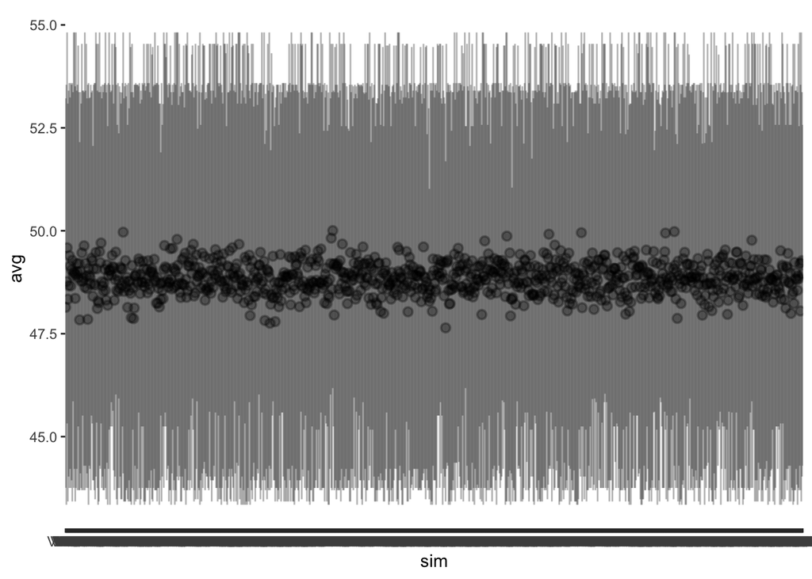

```r
ggplot(data = biden_boot_stats,
       mapping = aes(x = sim,
                     y = avg,
                     ymin = ci_lower,
                     ymax = ci_upper)) +
  geom_pointrange(alpha = 0.3)
```

###### 5d. So…. what is that plot showing? What are the concepts involved?

The CIs are very large, and expand far beyond the initial mean value of the data.  
These error bars reflect how precise the data is, i.e. the uncertainty.